# Forecasting Using R

Manuela da Cruz Chadreque

20 de Maio de 2019

# Forecasting Using R

## Exploring and visualizing time series in R

Creating time series objects in R

```r
setwd("C:/Users/maiam/Dropbox/PROFESSIONAL DEVELOPMENT/DATA SCIENCE/01_R/Quantitative Analyst with R/Forecasting Using R")
library(readxl)
# Read the data from Excel into R
mydata <- read_excel("exercise1.xlsx")
# Look at the first few lines of mydata
head(mydata)
```

```
## # A tibble: 6 x 4
##   ..1    Sales AdBudget   GDP
##   <chr>  <dbl>    <dbl> <dbl>
## 1 Mar-81 1020.     659.  252.
## 2 Jun-81  889.     589   291.
## 3 Sep-81  795      512.  291.
## 4 Dec-81 1004.     614.  292.
## 5 Mar-82 1058.     647.  279.
## 6 Jun-82  944.     602   254
```

```r
# Create a ts object called myts
myts <- ts(mydata[,2:4], start = c(1981, 1), frequency = 4)
```

Time series plots Graphs enable you to visualize many features of the data, including patterns, unusual observations, changes over time, and relationships between variables.

```r
library(forecast)
```

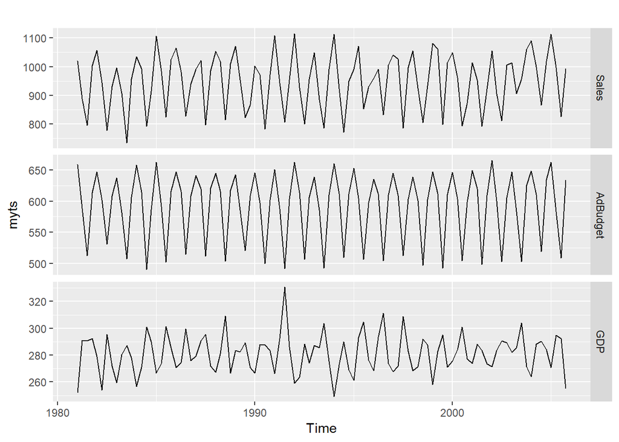

```r
# Plot the data with facetting
autoplot(myts, facets = TRUE)
```

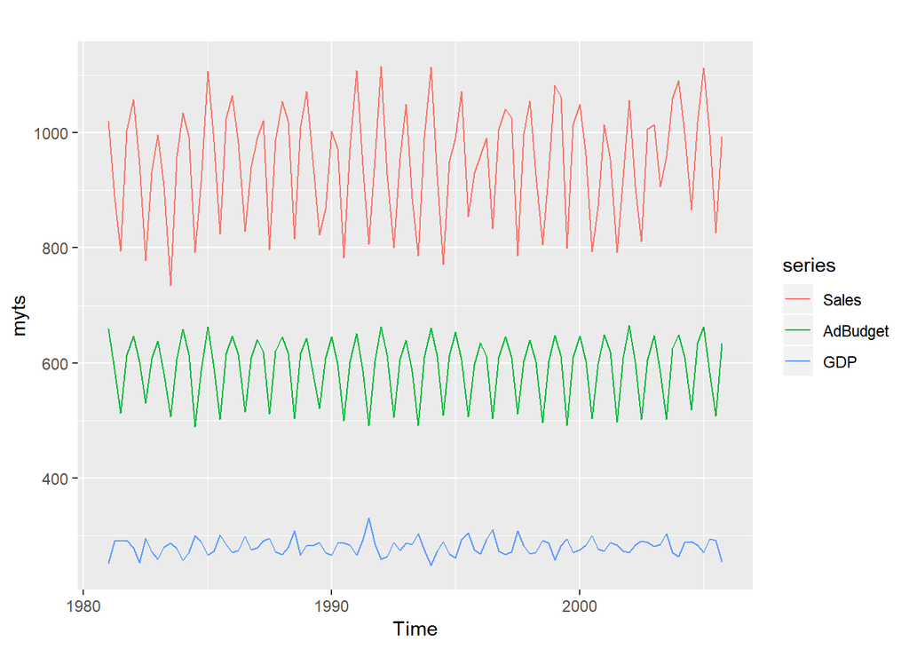

```r
# Plot the data without facetting
autoplot(myts, facets = FALSE)
```

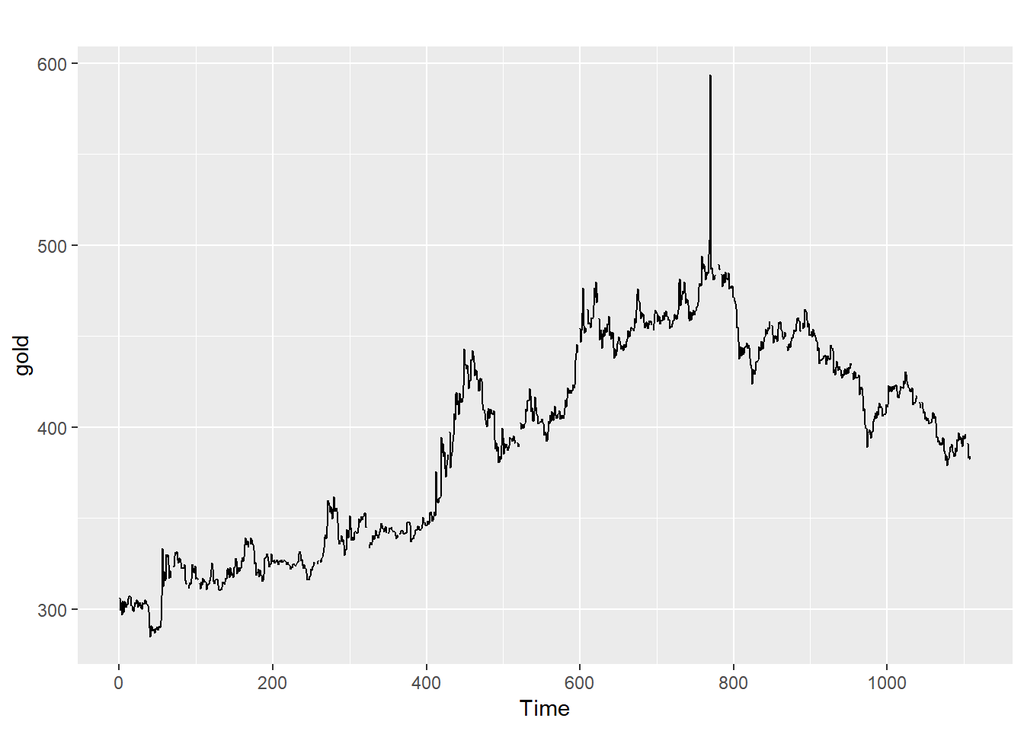

```r
# Plot the three series
autoplot(gold)
```

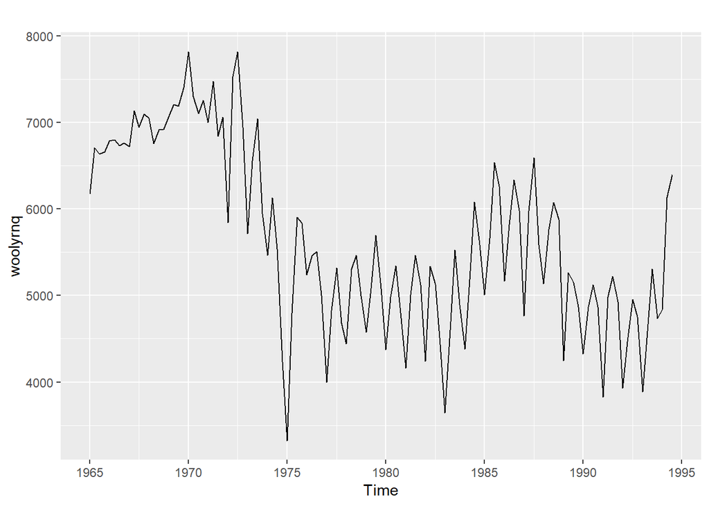

```r
autoplot(woolyrnq)
```

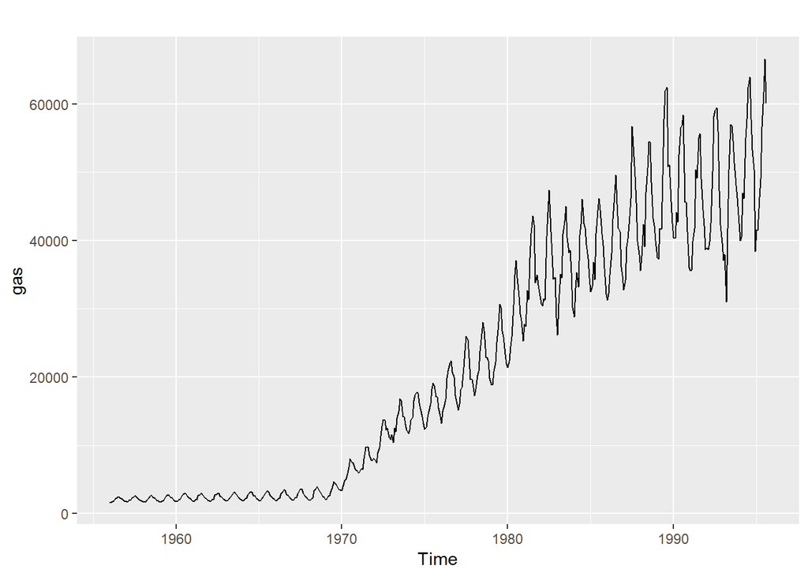

```r
autoplot(gas)
```

```r
# Find the outlier in the gold series
goldoutlier <- which.max(gold)

# Look at the seasonal frequencies of the three series
frequency(gold)
```

```
## [1] 1
```

```r
frequency(woolyrnq)
```

```
## [1] 4
```

```r
frequency(gas)
```

```
## [1] 12
```

Seasonal plots

```r
# Load the fpp2 package
library(fpp2)
```

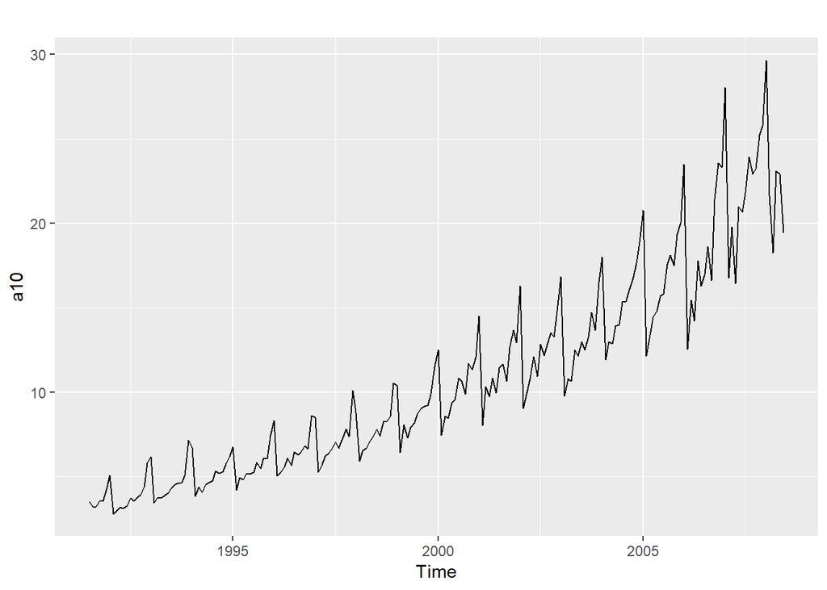

```r
# Create plots of the a10 data
autoplot(a10)
```

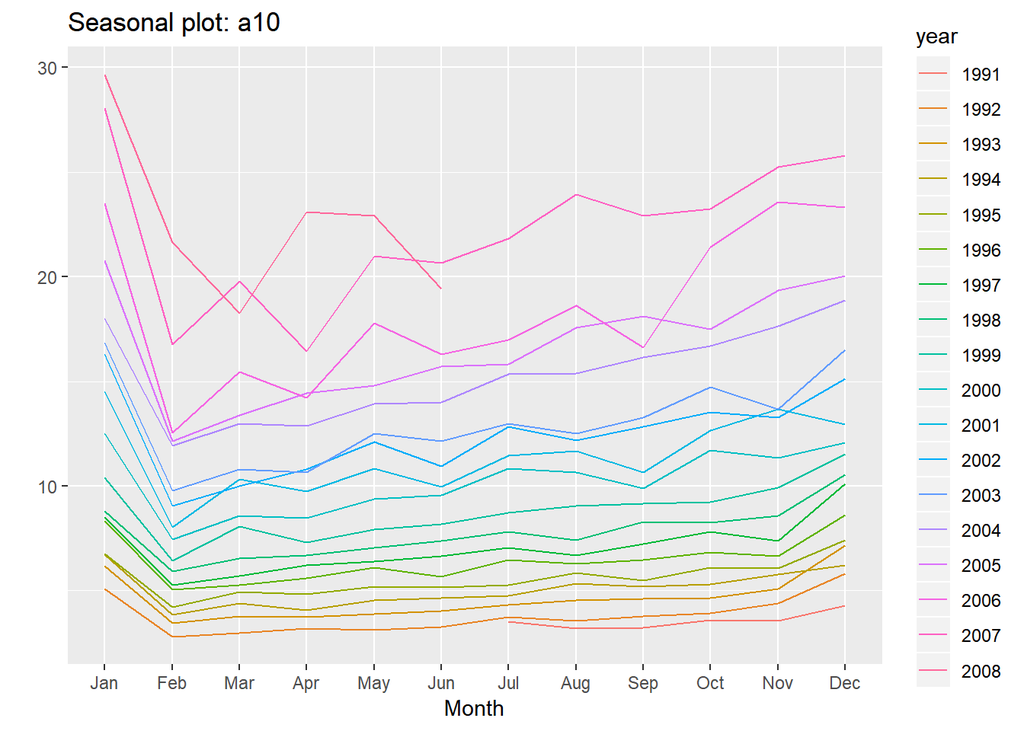

```r
ggseasonplot(a10)
```

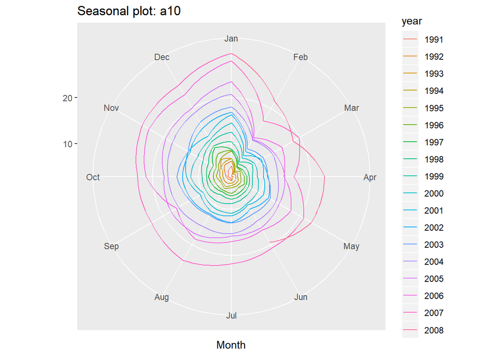

```r
# Produce a polar coordinate season plot for the a10 data
ggseasonplot(a10, polar = TRUE)
```

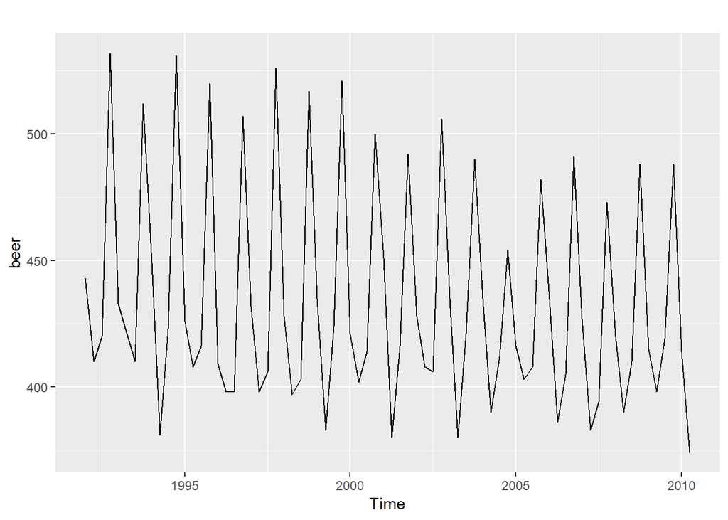

```r
# Restrict the ausbeer data to start in 1992
beer <- window(ausbeer, start=1992)

# Make plots of the beer data
autoplot(beer)
```

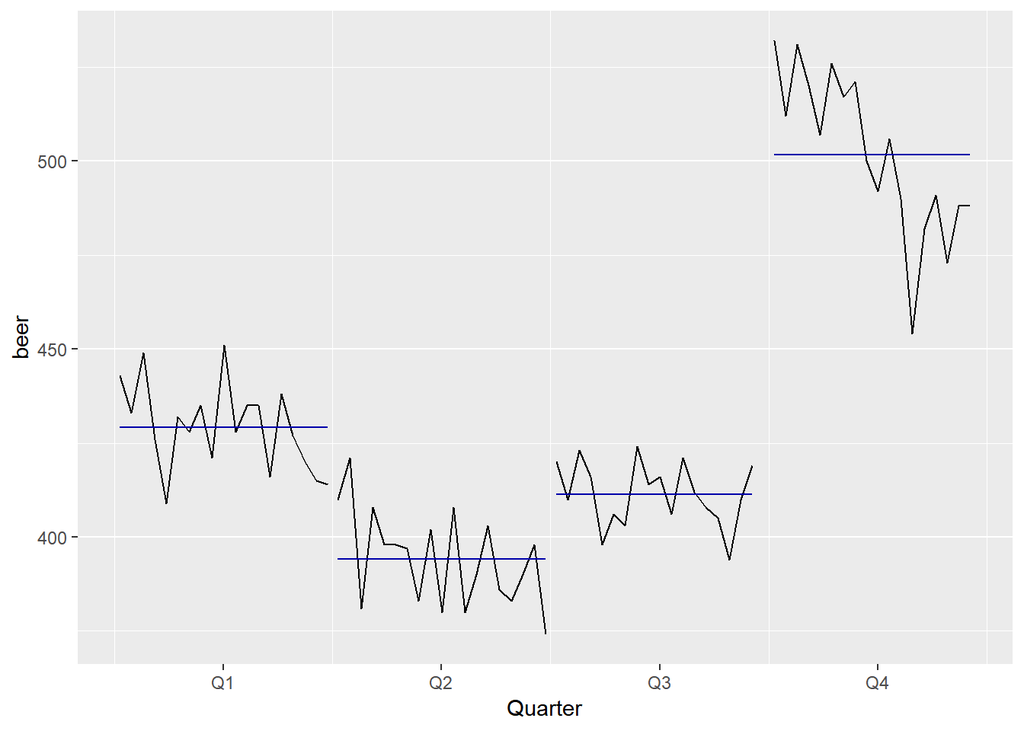

```r
ggsubseriesplot(beer)
```

## Trends, seasonality and cyclicity

Autocorrelation of non-seasonal time series

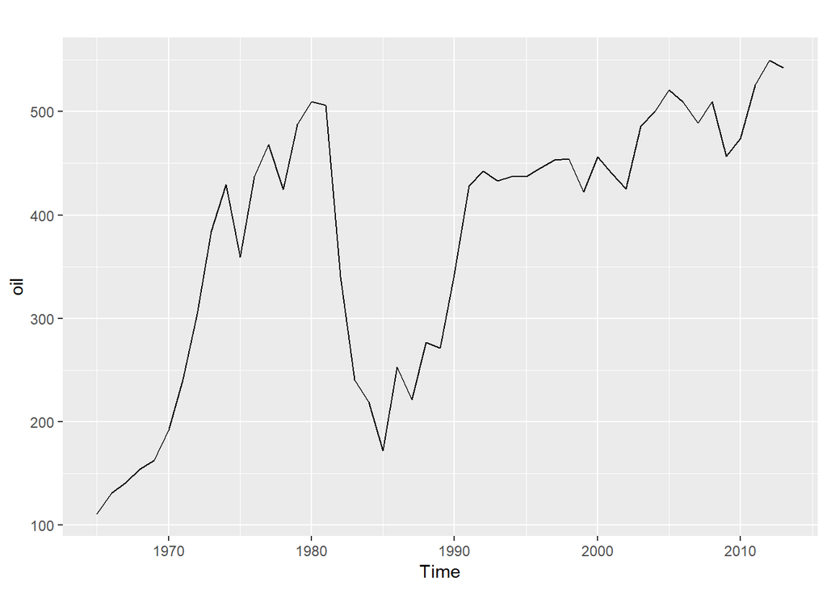

```r
# Create an autoplot of the oil data
autoplot(oil)
```

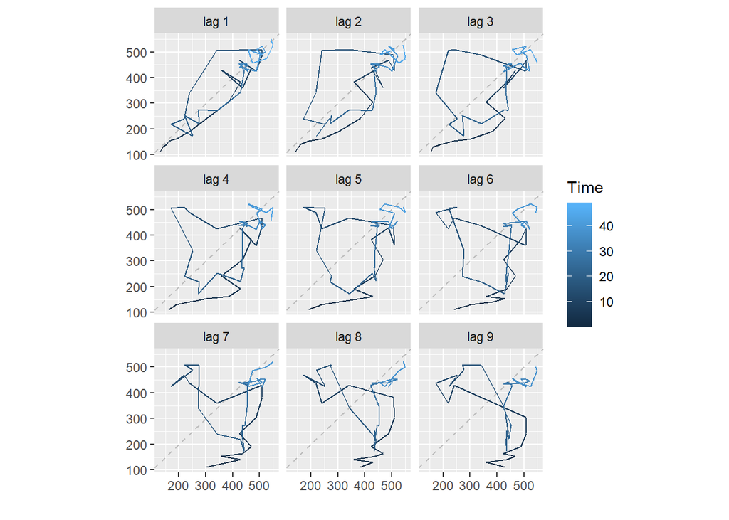

```r
# Create a lag plot of the oil data
gglagplot(oil)
```

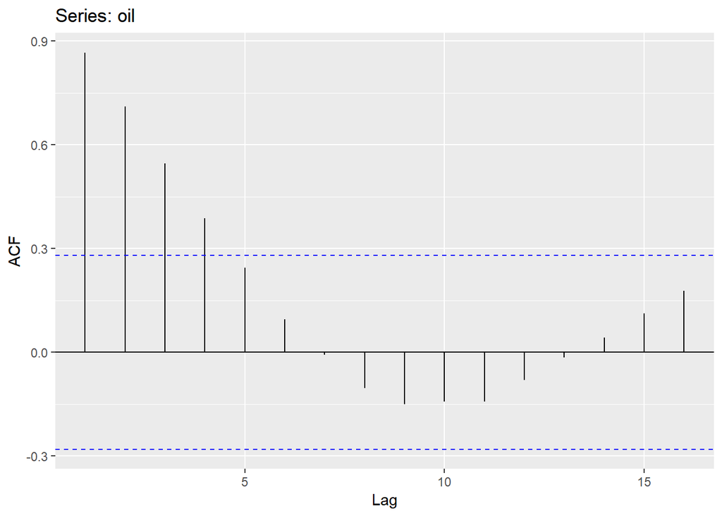

```r
# Create an ACF plot of the oil data
ggAcf(oil)
```

Autocorrelation of seasonal and cyclic time series

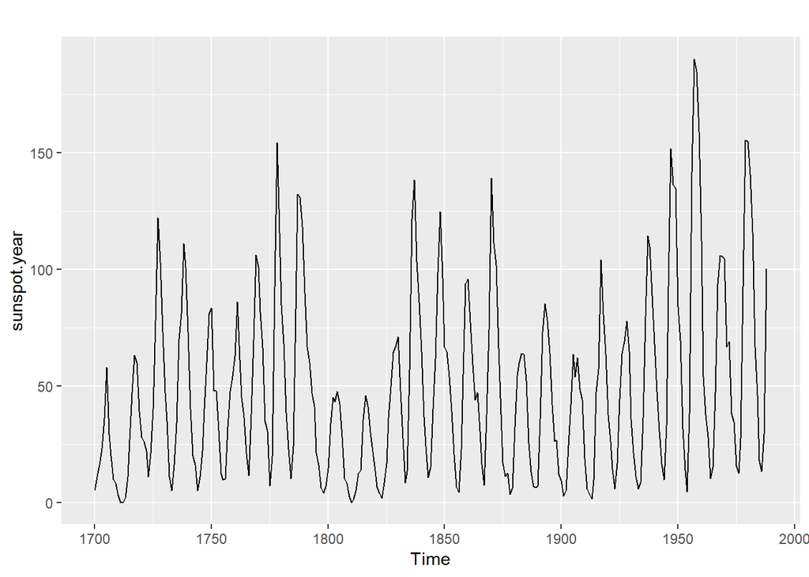

```r
# Plot the annual sunspot numbers
autoplot(sunspot.year)
```

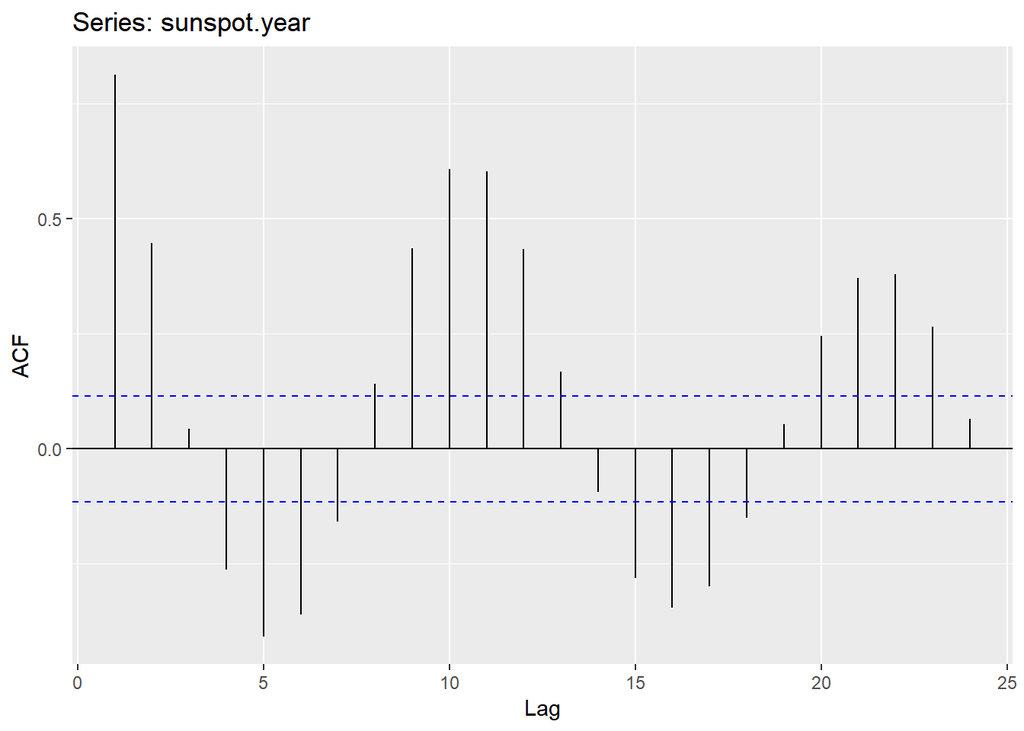

```r
ggAcf(sunspot.year)
```

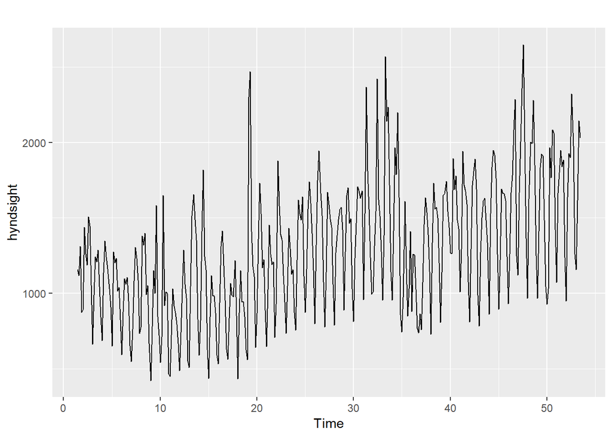

```r
# Save the lag corresponding to maximum autocorrelation
maxlag_sunspot <- 1

# Plot the traffic on the Hyndsight blog
autoplot(hyndsight)
```

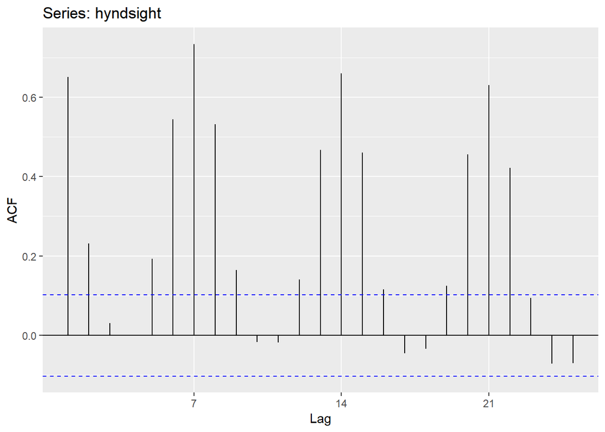

```r
ggAcf(hyndsight)
```

```r
# Save the lag corresponding to maximum autocorrelation
maxlag_hyndsight <- 7
```

White noise

Stock prices and white noise , white noise is a term that describes purely random data. You can conduct a Ljung-Box test using the function Box.test

There is a well-known result in economics called the “Efficient Market Hypothesis” that states that asset prices reflect all available information. A consequence of this is that the daily changes in stock prices should behave like white noise (ignoring dividends, interest rates and transaction costs). The consequence for forecasters is that the best forecast of the future price is the current price.

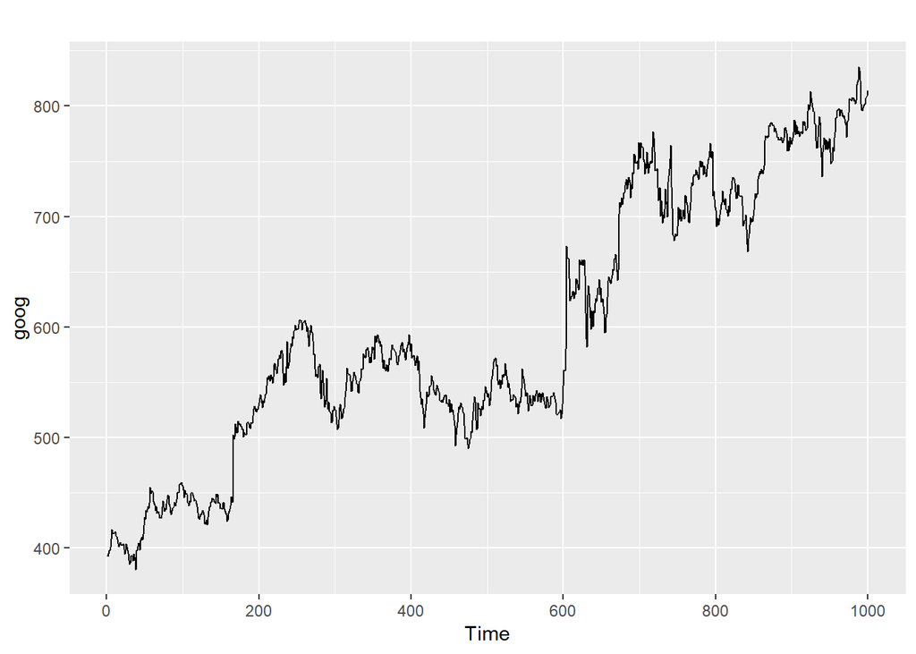

```r
# Plot the original series
autoplot(goog)
```

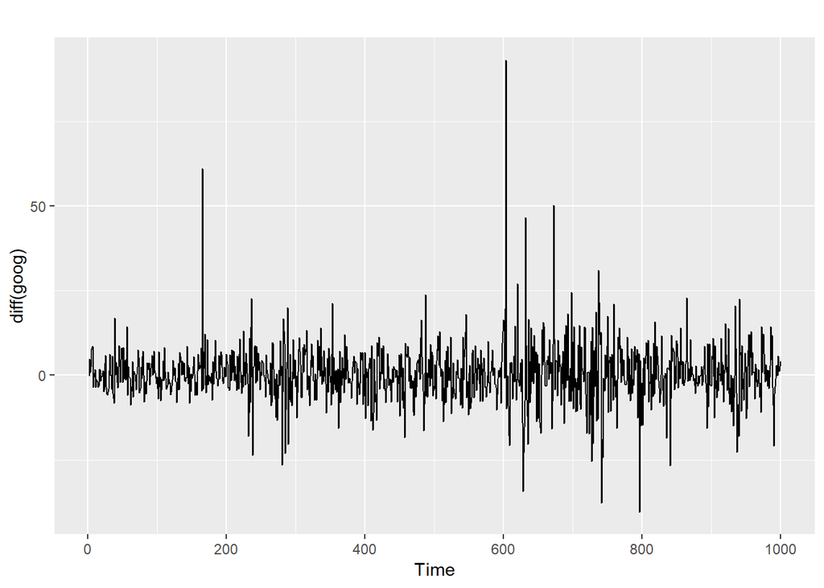

```r
# Plot the differenced series
autoplot(diff(goog))
```

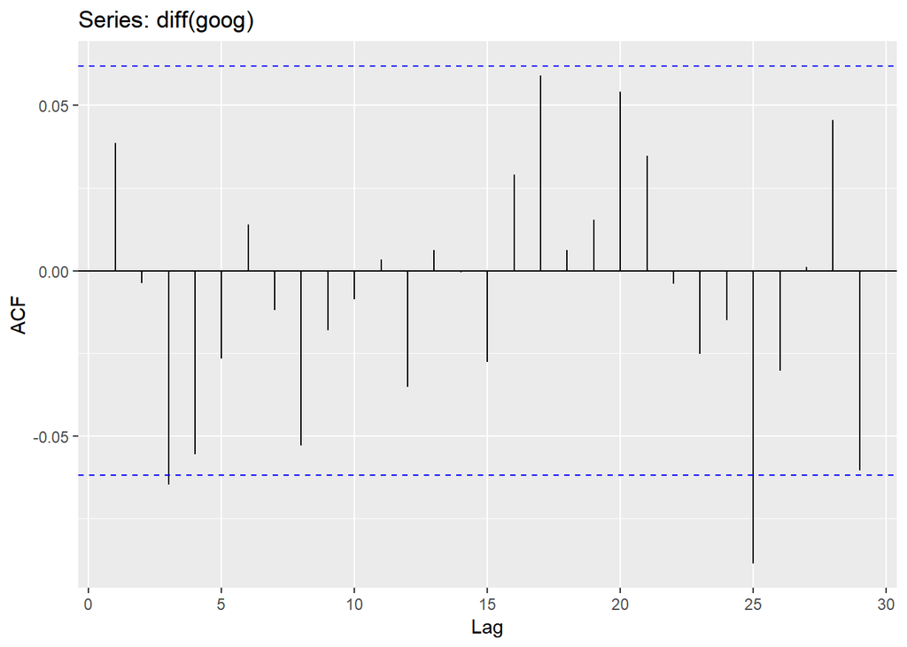

```r
# ACF of the differenced series
ggAcf(diff(goog))
```

```r
# Ljung-Box test of the differenced series
Box.test(diff(goog), lag = 10, type = "Ljung")
```

```
##
##  Box-Ljung test
##
## data:  diff(goog)
## X-squared = 13.123, df = 10, p-value = 0.2169
```

# Forecasts and potential futures

Naive forecasting methods a forecast is the mean or median of simulated futures of a time series.

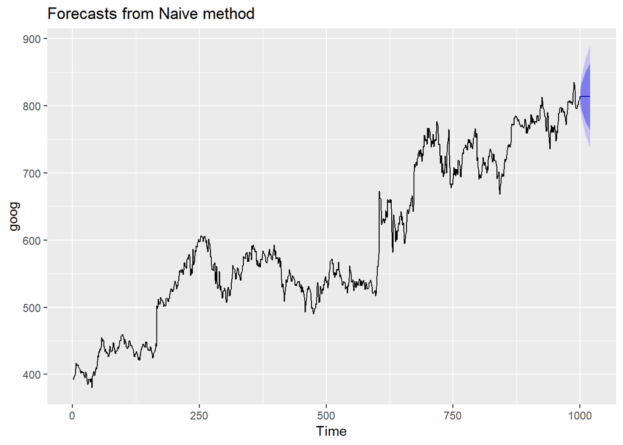

```r
# Use naive() to forecast the goog series
fcgoog <- naive(goog, h=20)

# Plot and summarize the forecasts
autoplot(fcgoog)
```

```r
summary(fcgoog)
```

```
##
## Forecast method: Naive method
##
## Model Information:
## Call: naive(y = goog, h = 20)
##
## Residual sd: 8.7285
##
## Error measures:
##                     ME     RMSE      MAE        MPE      MAPE MASE
## Training set 0.4212612 8.734286 5.829407 0.06253998 0.9741428    1
##                    ACF1
## Training set 0.03871446
##
## Forecasts:
##      Point Forecast    Lo 80    Hi 80    Lo 95    Hi 95
## 1001         813.67 802.4765 824.8634 796.5511 830.7889
## 1002         813.67 797.8401 829.4999 789.4602 837.8797
## 1003         813.67 794.2824 833.0576 784.0192 843.3208
## 1004         813.67 791.2831 836.0569 779.4322 847.9078
## 1005         813.67 788.6407 838.6993 775.3910 851.9490
## 1006         813.67 786.2518 841.0882 771.7374 855.6025
## 1007         813.67 784.0549 843.2850 768.3777 858.9623
## 1008         813.67 782.0102 845.3298 765.2505 862.0895
## 1009         813.67 780.0897 847.2503 762.3133 865.0266
## 1010         813.67 778.2732 849.0667 759.5353 867.8047
## 1011         813.67 776.5456 850.7944 756.8931 870.4469
## 1012         813.67 774.8948 852.4452 754.3684 872.9715
## 1013         813.67 773.3115 854.0285 751.9470 875.3930
## 1014         813.67 771.7880 855.5520 749.6170 877.7230
## 1015         813.67 770.3180 857.0220 747.3688 879.9711
## 1016         813.67 768.8962 858.4437 745.1944 882.1455
## 1017         813.67 767.5183 859.8217 743.0870 884.2530
## 1018         813.67 766.1802 861.1597 741.0407 886.2993
## 1019         813.67 764.8789 862.4610 739.0505 888.2895
## 1020         813.67 763.6114 863.7286 737.1120 890.2280
```

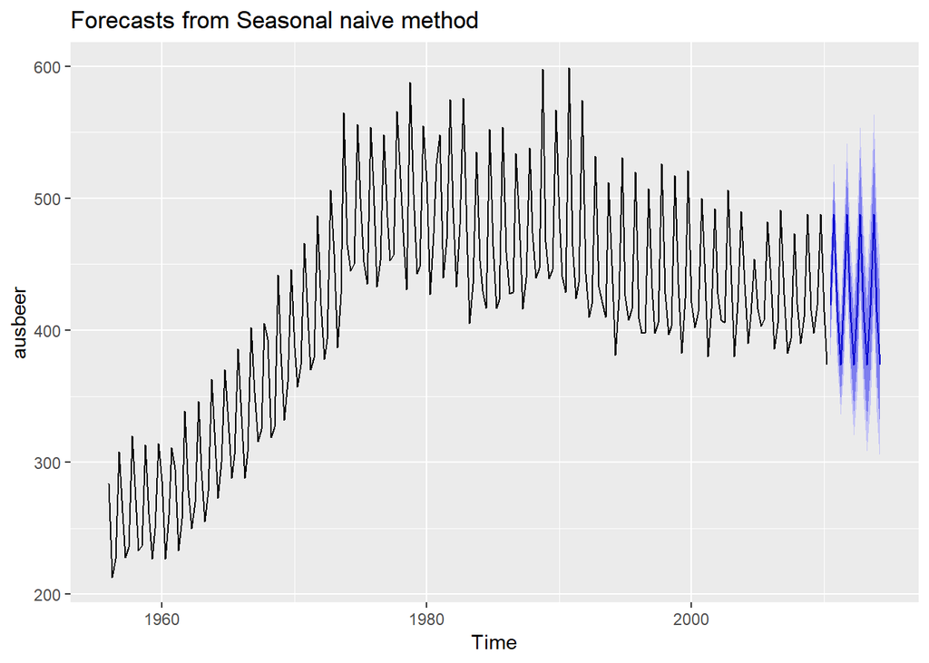

```r
# Use snaive() to forecast the ausbeer series
fcbeer <- snaive(ausbeer,h=16)

# Plot and summarize the forecasts
autoplot(fcbeer)
```

```r
summary(fcbeer)
```

```
##
## Forecast method: Seasonal naive method
##
## Model Information:
## Call: snaive(y = ausbeer, h = 16)
##
## Residual sd: 19.1207
##
## Error measures:
##                    ME     RMSE      MAE      MPE    MAPE MASE       ACF1
## Training set 3.098131 19.32591 15.50935 0.838741 3.69567    1 0.01093868
##
## Forecasts:
##         Point Forecast    Lo 80    Hi 80    Lo 95    Hi 95
## 2010 Q3            419 394.2329 443.7671 381.1219 456.8781
## 2010 Q4            488 463.2329 512.7671 450.1219 525.8781
## 2011 Q1            414 389.2329 438.7671 376.1219 451.8781
## 2011 Q2            374 349.2329 398.7671 336.1219 411.8781
## 2011 Q3            419 383.9740 454.0260 365.4323 472.5677
## 2011 Q4            488 452.9740 523.0260 434.4323 541.5677
## 2012 Q1            414 378.9740 449.0260 360.4323 467.5677
## 2012 Q2            374 338.9740 409.0260 320.4323 427.5677
## 2012 Q3            419 376.1020 461.8980 353.3932 484.6068
## 2012 Q4            488 445.1020 530.8980 422.3932 553.6068
## 2013 Q1            414 371.1020 456.8980 348.3932 479.6068
## 2013 Q2            374 331.1020 416.8980 308.3932 439.6068
## 2013 Q3            419 369.4657 468.5343 343.2438 494.7562
## 2013 Q4            488 438.4657 537.5343 412.2438 563.7562
## 2014 Q1            414 364.4657 463.5343 338.2438 489.7562
## 2014 Q2            374 324.4657 423.5343 298.2438 449.7562
```

Fitted values and residuals Checking time series residuals When applying a forecasting method, it is important to always check that the residuals are well-behaved (i.e., no outliers or patterns) and resemble white noise. The prediction intervals are computed assuming that the residuals are also normally distributed. You can use the checkresiduals() function to verify these characteristics; it will give the results of a Ljung-Box test.

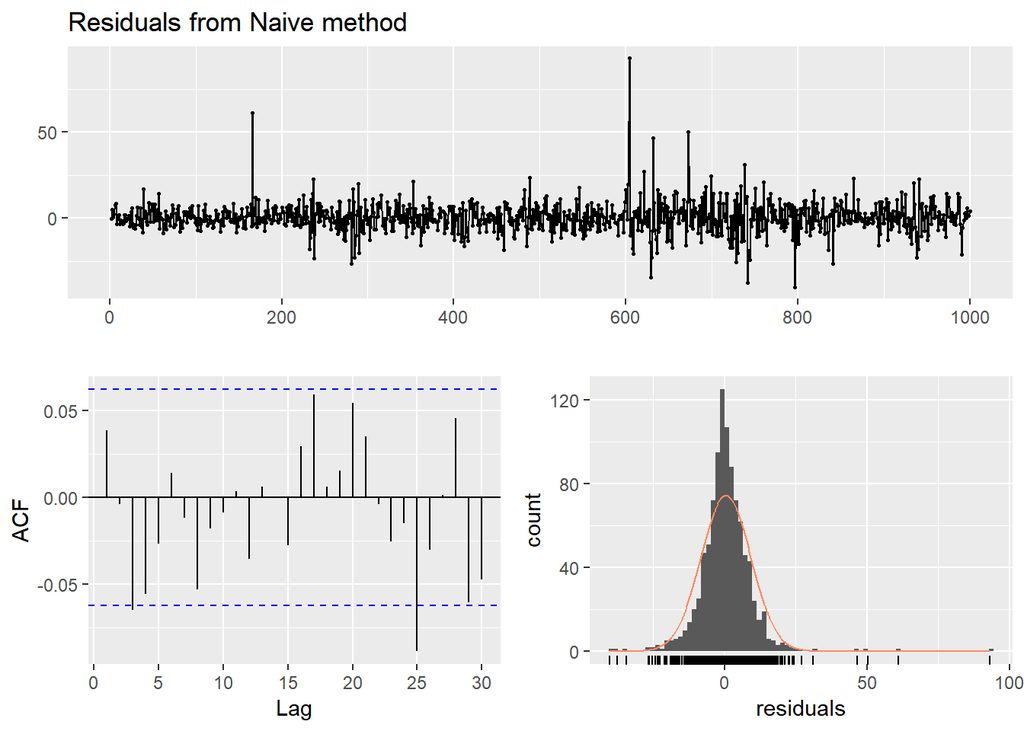

```
##
##  Ljung-Box test
##
## data:  Residuals from Naive method
## Q* = 13.123, df = 10, p-value = 0.2169
##
## Model df: 0.   Total lags used: 10
```

```r
# Check the residuals from the naive forecasts applied to the goog series
goog %>% naive() %>% checkresiduals()
```

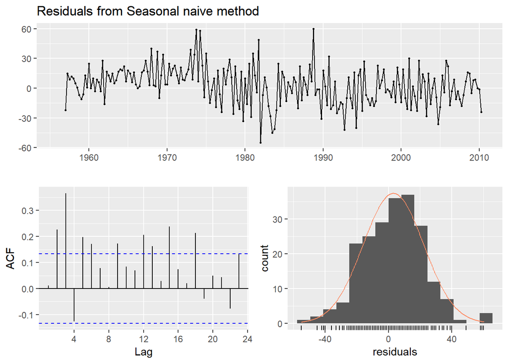

```
##
##  Ljung-Box test
##
## data:  Residuals from Seasonal naive method
## Q* = 60.535, df = 8, p-value = 3.661e-10
##
## Model df: 0.   Total lags used: 8
```

```r
# Do they look like white noise (TRUE or FALSE)
googwn <-TRUE

# Check the residuals from the seasonal naive forecasts applied to the ausbeer series

ausbeer %>% snaive() %>% checkresiduals()
```

```r
# Do they look like white noise (TRUE or FALSE)
beerwn <- FALSE
```

## Evaluating forecast accuracy of non-seasonal methods

a training set is a data set that is used to discover possible relationships. A test set is a data set that is used to verify the strength of these potential relationships. When you separate a data set into these parts, you generally allocate more of the data for training, and less for testing.

```r
# Create the training data as train
train <- subset(gold, end = 1000)

# Compute naive forecasts and save to naive_fc
naive_fc <- naive(train, h = 108)

# Compute mean forecasts and save to mean_fc
mean_fc <- meanf(train, h = 108)

# Use accuracy() to compute RMSE statistics
accuracy(naive_fc, gold)
```

```
##                      ME      RMSE      MAE        MPE      MAPE     MASE
## Training set  0.1079897  6.358087  3.20366  0.0201449 0.8050646 1.014334
## Test set     -6.5383495 15.842361 13.63835 -1.7462269 3.4287888 4.318139
##                    ACF1 Theil's U
## Training set -0.3086638        NA
## Test set      0.9793153  5.335899
```

```r
accuracy(mean_fc, gold)
```

```
##                         ME     RMSE      MAE       MPE      MAPE      MASE
## Training set -4.239671e-15 59.17809 53.63397 -2.390227 14.230224 16.981449
## Test set      1.319363e+01 19.55255 15.66875  3.138577  3.783133  4.960998
##                   ACF1 Theil's U
## Training set 0.9907254        NA
## Test set     0.9793153  6.123788
```

```r
# Assign one of the two forecasts as bestforecasts
bestforecasts <-naive_fc
```

# Evaluating forecast accuracy of seasonal methods

window() function specifies the start and end of a time series using the relevant times rather than the index values. Either of those two arguments can be formatted as a vector like c(year, period) which you have also previously used as an argument for ts(). Again, period refers to quarter here.

```r
library(forecast)
library(fpp2)
library(fpp)
```

```r
# Create three training series omitting the last 1, 2, and 3 years
train1 <- window(vn[, "Melbourne"], end = c(2010,4))
train2 <- window(vn[, "Melbourne"], end = c(2009,4))
train3 <- window(vn[, "Melbourne"], end = c(2008,4))

# Produce forecasts using snaive()
fc1 <- snaive(train1, h = 4)
fc2 <- snaive(train2, h = 4)
fc3 <- snaive(train3, h = 4)

# Use accuracy() to compare the MAPE of each series
accuracy(fc1, vn[, "Melbourne"])["Test set", "MAPE"]
```

```
## [1] 3.456972
```

```r
accuracy(fc2, vn[, "Melbourne"])["Test set", "MAPE"]
```

```
## [1] 3.553828
```

```r
accuracy(fc3, vn[, "Melbourne"])["Test set", "MAPE"]
```

```
## [1] 7.322694
```

## Time series cross-validation

Using tsCV() for time series cross-validation The tsCV() function computes time series cross-validation errors. It requires you to specify the time series, the forecast method, and the forecast horizon

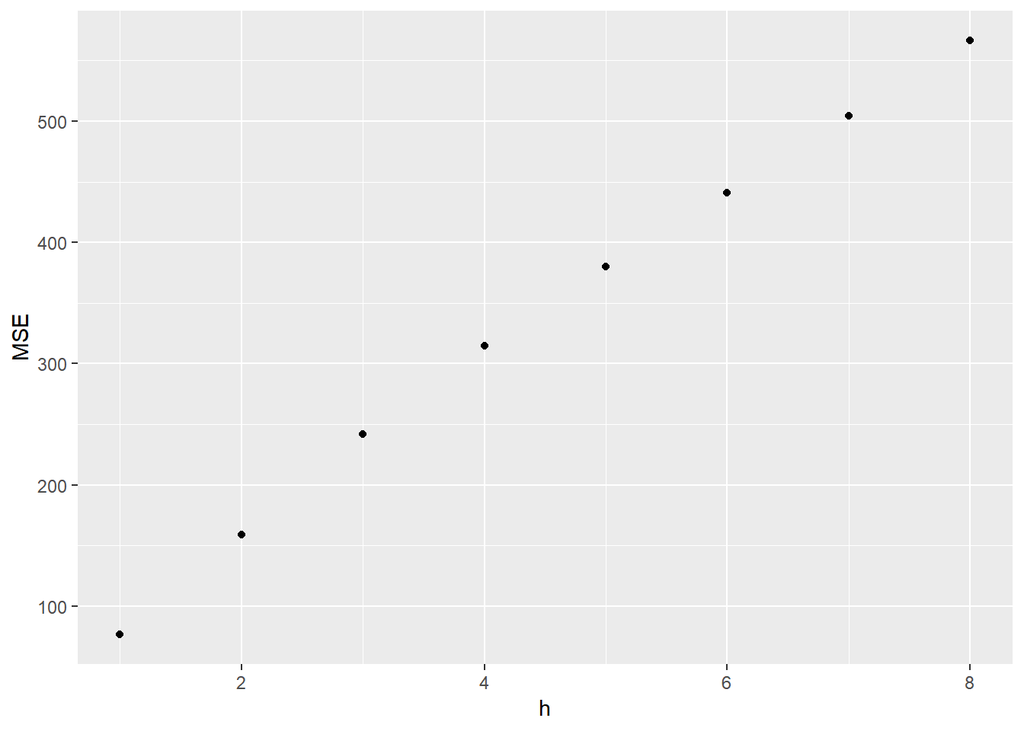

```r
library(fpp2)
# Compute cross-validated errors for up to 8 steps ahead
e <- tsCV(goog, forecastfunction = naive, h = 8)

# Compute the MSE values and remove missing values
mse <- colMeans(e^2, na.rm = TRUE)

# Plot the MSE values against the forecast horizon
data.frame(h = 1:8, MSE = mse) %>%
  ggplot(aes(x = h, y = MSE)) + geom_point()
```

# Exponential smoothing

The ses() function produces forecasts obtained using simple exponential smoothing (SES). The parameters are estimated using least squares estimation.

```r
# Use ses() to forecast the next 10 years of winning times
fc <- ses(marathon, h = 10)

# Use summary() to see the model parameters
summary(fc)
```

```
##
## Forecast method: Simple exponential smoothing
##
## Model Information:
## Simple exponential smoothing
##
## Call:
##  ses(y = marathon, h = 10)
##
##   Smoothing parameters:
##     alpha = 0.3457
##
##   Initial states:
##     l = 167.1741
##
##   sigma:  5.519
##
##      AIC     AICc      BIC
## 988.4474 988.6543 996.8099
##
## Error measures:
##                      ME     RMSE      MAE        MPE     MAPE      MASE
## Training set -0.8874349 5.472771 3.826294 -0.7097395 2.637644 0.8925685
##                     ACF1
## Training set -0.01211236
##
## Forecasts:
##      Point Forecast    Lo 80    Hi 80    Lo 95    Hi 95
## 2017       130.3563 123.2835 137.4292 119.5394 141.1733
## 2018       130.3563 122.8727 137.8399 118.9111 141.8015
## 2019       130.3563 122.4833 138.2293 118.3156 142.3970
## 2020       130.3563 122.1123 138.6003 117.7482 142.9644
## 2021       130.3563 121.7573 138.9553 117.2053 143.5074
## 2022       130.3563 121.4164 139.2963 116.6839 144.0288
## 2023       130.3563 121.0880 139.6247 116.1816 144.5310
## 2024       130.3563 120.7708 139.9418 115.6966 145.0161
## 2025       130.3563 120.4639 140.2488 115.2271 145.4856
## 2026       130.3563 120.1661 140.5466 114.7717 145.9409
```

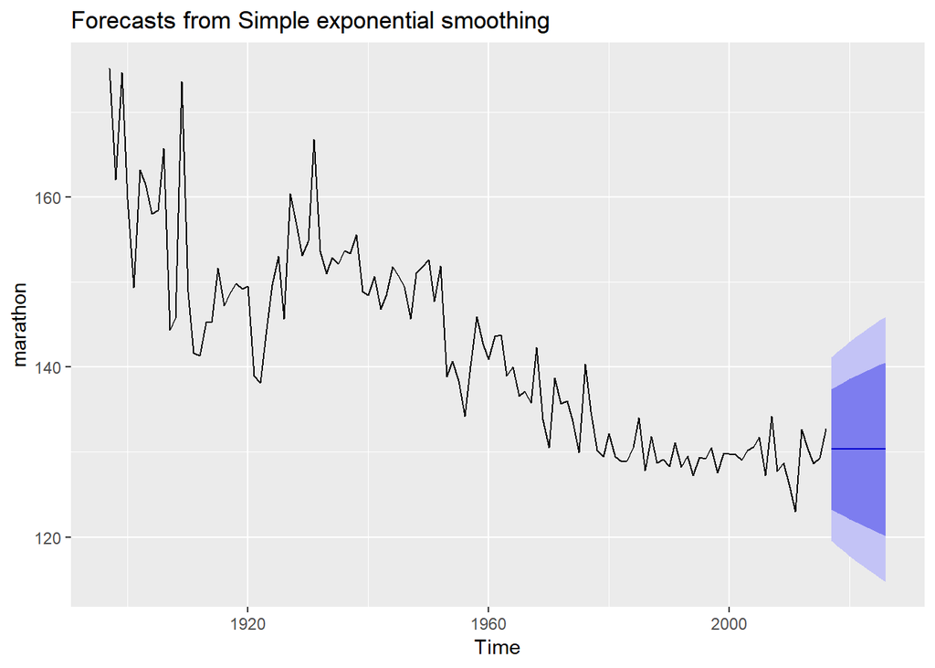

```r
# Use autoplot() to plot the forecasts
autoplot(fc)
```

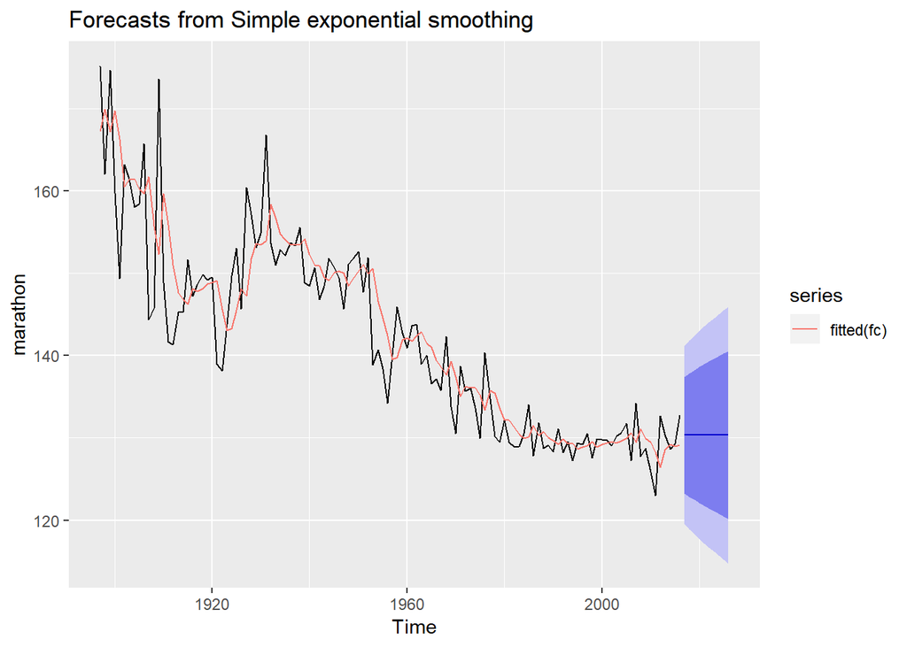

```r
# Add the one-step forecasts for the training data to the plot
autoplot(fc) + autolayer(fitted(fc))
```

SES vs naive

Let’s review the process:

1. First, import and load your data. Determine how much of your data you want to allocate to training, and how much to testing; the sets should not overlap.
2. Subset the data to create a training set, which you will use as an argument in your forecasting function(s). Optionally, you can also create a test set to use later.
3. Compute forecasts of the training set using whichever forecasting function(s) you choose, and set h equal to the number of values you want to forecast, which is also the length of the test set.
4. To view the results, use the accuracy() function with the forecast as the first argument and original data (or test set) as the second.
5. Pick a measure in the output, such as RMSE or MAE, to evaluate the forecast(s); a smaller error indicates higher accuracy.

```r
# Create a training set using subset()
train <- subset(marathon, end = length(marathon) - 20)

# Compute SES and naive forecasts, save to fcses and fcnaive
fcses <- ses(train, h = 20)
fcnaive <- naive(train, h = 20)

# Calculate forecast accuracy measures
accuracy(fcses, marathon)
```

```
##                      ME     RMSE      MAE        MPE     MAPE      MASE
## Training set -1.0851741 5.863790 4.155948 -0.8603998 2.827993 0.8990906
## Test set      0.4574579 2.493971 1.894237  0.3171919 1.463862 0.4097960
##                     ACF1 Theil's U
## Training set -0.01595953        NA
## Test set     -0.12556096 0.6870735
```

```r
accuracy(fcnaive, marathon)
```

```
##                      ME     RMSE      MAE        MPE     MAPE      MASE
## Training set -0.4638047 6.904742 4.622391 -0.4086317 3.123559 1.0000000
## Test set      0.2266667 2.462113 1.846667  0.1388780 1.429608 0.3995047
##                    ACF1 Theil's U
## Training set -0.3589323        NA
## Test set     -0.1255610 0.6799062
```

```r
# Save the best forecasts as fcbest
fcbest <- fcnaive
```

Exponential smoothing methods with trend Holt’s trend methods

```r
# Produce 10 year forecasts of austa using holt()
fcholt <- holt(austa,h=10)

# Look at fitted model using summary()
summary(fcholt)
```

```
##
## Forecast method: Holt's method
##
## Model Information:
## Holt's method
##
## Call:
##  holt(y = austa, h = 10)
##
##   Smoothing parameters:
##     alpha = 0.9999
##     beta  = 1e-04
##
##   Initial states:
##     l = 0.2649
##     b = 0.1552
##
##   sigma:  0.2026
##
##      AIC     AICc      BIC
## 13.17520 15.57520 20.34514
##
## Error measures:
##                      ME     RMSE       MAE       MPE     MAPE      MASE
## Training set 0.01176412 0.189043 0.1639816 0.4689497 7.772067 0.8726718
##                   ACF1
## Training set 0.1059603
##
## Forecasts:
##      Point Forecast    Lo 80    Hi 80    Lo 95    Hi 95
## 2011       5.596083 5.336488 5.855677 5.199067 5.993098
## 2012       5.751282 5.384160 6.118404 5.189817 6.312747
## 2013       5.906482 5.456836 6.356128 5.218807 6.594157
## 2014       6.061682 5.542453 6.580910 5.267590 6.855773
## 2015       6.216881 5.636340 6.797423 5.329020 7.104743
## 2016       6.372081 5.736100 7.008062 5.399431 7.344731
## 2017       6.527281 5.840309 7.214252 5.476649 7.577913
## 2018       6.682480 5.948041 7.416919 5.559253 7.805708
## 2019       6.837680 6.058652 7.616709 5.646259 8.029101
## 2020       6.992880 6.171671 7.814088 5.736950 8.248810
```

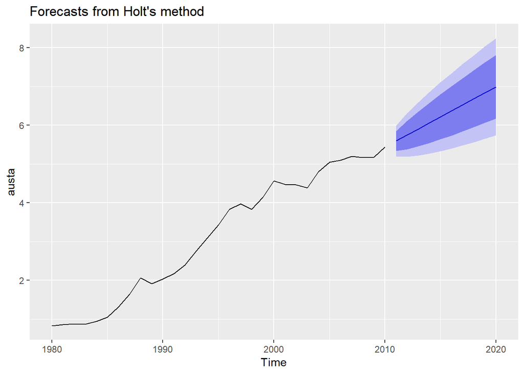

```r
# Plot the forecasts
autoplot(fcholt)
```

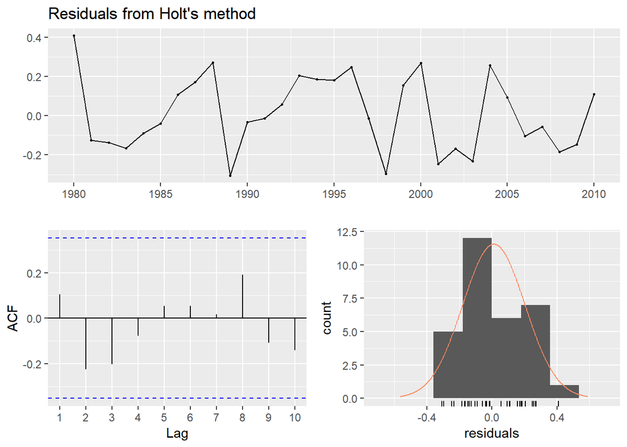

```
##
##  Ljung-Box test
##
## data:  Residuals from Holt's method
## Q* = 4.1215, df = 3, p-value = 0.2486
##
## Model df: 4.   Total lags used: 7
```

```r
# Check that the residuals look like white noise
checkresiduals(fcholt)
```

Exponential smoothing methods with trend and seasonality

Holt-Winters with monthly data

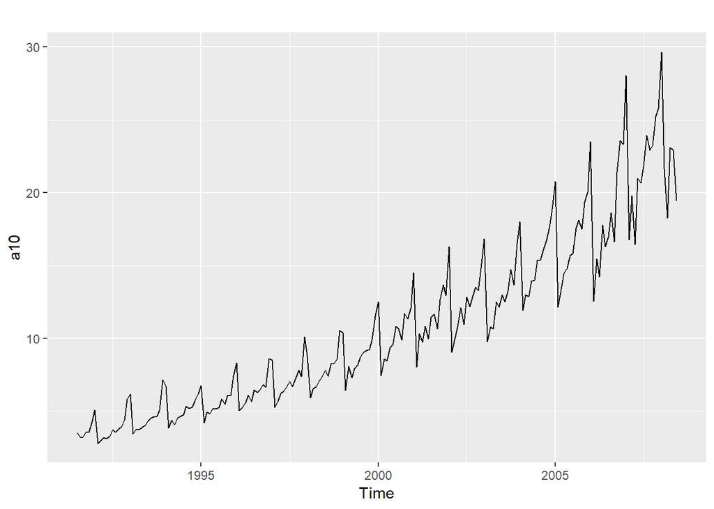

```r
# Plot the data
autoplot(a10)
```

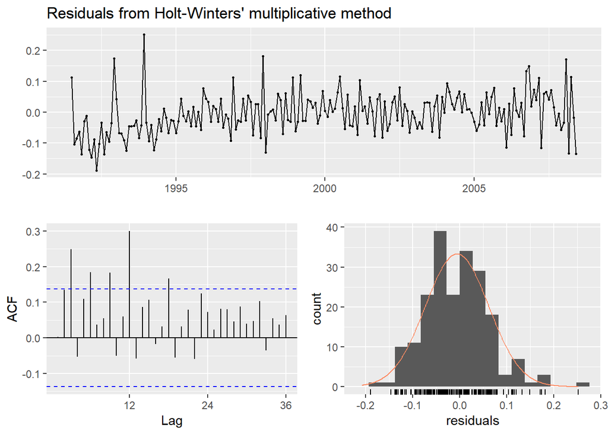

```
##
##  Ljung-Box test
##
## data:  Residuals from Holt-Winters' multiplicative method
## Q* = 75.764, df = 8, p-value = 3.467e-13
##
## Model df: 16.   Total lags used: 24
```

```r
# Produce 3 year forecasts
fc <- hw(a10, seasonal ="multiplicative" , h = 36)

# Check if residuals look like white noise
checkresiduals(fc)
```

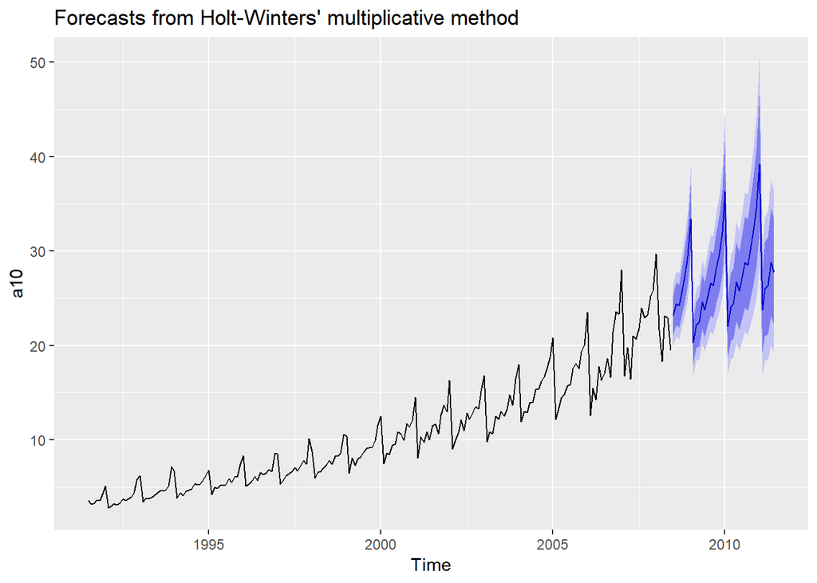

```r
whitenoise <- FALSE

# Plot forecasts
autoplot(fc)
```

Holt-Winters method with daily data

```r
# Create training data with subset()
train <- subset(hyndsight, end =337)

# Holt-Winters additive forecasts as fchw
fchw <- hw(train, seasonal = "additive", h = 28)

# Seasonal naive forecasts as fcsn
fcsn <- snaive(train,h=28)

# Find better forecasts with accuracy()
accuracy(fchw,hyndsight)
```

```
##                     ME     RMSE      MAE       MPE    MAPE      MASE
## Training set -3.976241 228.2440 165.0244 -2.407211 13.9955 0.7492131
## Test set     -3.999460 201.7656 152.9584 -3.218292 10.5558 0.6944332
##                   ACF1 Theil's U
## Training set 0.1900853        NA
## Test set     0.3013328 0.4868701
```

```r
accuracy(fcsn,hyndsight)
```

```
##                 ME     RMSE      MAE        MPE     MAPE      MASE
## Training set 10.50 310.3282 220.2636 -2.1239387 18.01077 1.0000000
## Test set      0.25 202.7610 160.4643 -0.6888732 10.25880 0.7285101
##                   ACF1 Theil's U
## Training set 0.4255730        NA
## Test set     0.3089795  0.450266
```